# UC business Analytics R programming Guide

#### 2.1.3.5 Comparing models

So far, I’ve illustrated how to perform the best subset and stepwise procedures. Now let’s discuss how to compare all the models that these approaches output in order to identify the *best* model. That is, let’s perform step 3 discussed in each of the 3-state processes outlined approaches.

1. We can indirectly estimate test error by making an adjustment to the training error to account for the bias due to ovefitting.
2. We can directly estimate the test error, using either a validation set approach or a cross-validation approach.

We consider both of these approaches below.

##### 2.1.3.5.1 Indirectly estimating test error with $C_p$, AIC, BIC and adjusted $R^2$

When performing the best subset or stepwise approaches, the $M_0,...,M_p$ models are selected based on the fact that they minimize the training set mean square error (MSE). Because of this and the fact that using the training MSE and $R^2$ will bias our results we should not use these statstics to determine which of the $M_0,...,M_p$ models is “the best”.

However, a number of technique for adjusting the training error for the model size are available. These approaches can be used to select among a set of models with different number of variables These include:

**Objective: Minimize** - $C_p$: $C_p = \frac{1}{n}(RSS+2d\hat{\sigma})$ - $Akaike information criterion$: $AIC = \frac{1}{n\hat{\sigma}}(RSS+2d\hat{\sigma^2})$ - $Bayesian information criterion(BIC): BIC = \frac{1}{n}(RSS + log(n)d\hat{\sigma)}$

**Objective: Maximize** - adjusted $R^2$: adj $R^2$ = 1 - $\frac{RSS/(n-d-1)}{TSS/(n-1)}$

where, $d$ is the number of predictors and $\sigma^2$ is an estimate of the variance of the error $\epsilon$ associated with each response measurement in a regression model. Each of these statistics adds a penalty to the training RSS in order to adjust for the fact that the training error tends to underestimate the test error. Clearly, the penalty increases as the number of predictors in the model increases.

Therefore, these statistics provide an unbiased estimate of test MSE. If we perform our model using a training vs. testing validation approach we can use these statistics to determine the preferred model. These statistics are contained in the output provided by the `regsubsets` function. Let’s extract this information and plot them.

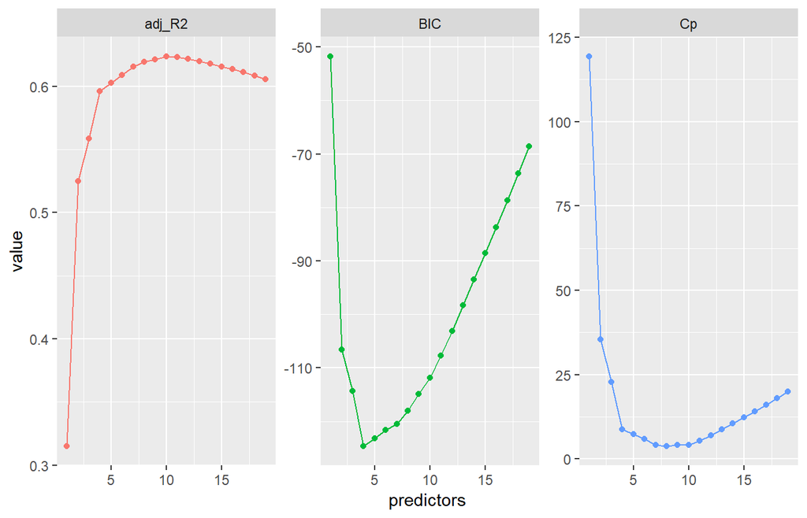

```r
# create training - testing data
set.seed(1)
sample <- sample(c(T,F), nrow(hitters), replace=T, prob = c(0.6, 0.4))
train <- hitters[sample,]
test <- hitters[!sample,]

# perform best subset selection
best_subset <- regsubsets(Salary~., train, nvmax = 19)
results <- summary(best_subset)

# extract and plot results
tibble(predictors = 1:19,
       adj_R2 = results$adjr2,
       Cp = results$cp,
       BIC = results$bic) %>%
  gather(statistic, value, -predictors) %>%
  ggplot(aes(predictors, value, color=statistic))+
  geom_line(show.legend = F)+
  geom_point(show.legend = F)+
  facet_wrap(~statistic, scales="free")
```

Here we see that our results identify slightly different models that are considered the best. The adjusted $R^2$ statistic suggests the 10 variable model is preferred, the BIC statistic suggests the 4 variable model, and the $C_p$ suggests the 8 variable model.

```r
which.max(results$adjr2)
```

```
## [1] 10
```

```r
which.min(results$bic)
```

```
## [1] 4
```

```r
min(results$bic)
```

```
## [1] -124.6282
```

```r
which.min(results$cp)
```

```
## [1] 8
```

We can compare the variables and coefficinets that these models include using the `coef` function.

```r
# 10 variable model
coef(best_subset, 10)
## (Intercept)       AtBat        Hits       Walks      CAtBat       CHits
## -47.3715661  -1.3695666   6.3013473   4.5757613  -0.3118794   1.4799307
##      CHmRun      CWalks     LeagueN   DivisionW     PutOuts
##   1.2971405  -0.5026157  62.5613310 -62.3548737   0.2527181

# 4 variable model
coef(best_subset, 4)
## (Intercept)        Runs      CAtBat       CHits     PutOuts
## -83.1199265   5.5530883  -0.4741822   2.0560595   0.3118252

# 8 variable model
coef(best_subset, 8)
## (Intercept)       AtBat        Hits       Walks      CAtBat       CHits
## -59.2371674  -1.4744877   6.6802515   4.4777879  -0.3203862   1.5160882
##      CHmRun      CWalks     PutOuts
##   1.1861142  -0.4714870   0.2748103
```

We could perform the same process using foward and backward stepwise selection and obtain even more options for optimal models. For example, if I assess the optimal $C_p$ for foward/backward stepwise, we see that they suggest that an 8 variable model minimizes the $C_p$ statsitic, similar to the best subset approach above.

```r
forward <- regsubsets(Salary ~ ., train, nvmax = 19, method = "forward")
backward <- regsubsets(Salary ~ ., train, nvmax = 19, method = "backward")

# which models minimize Cp?
which.min(summary(forward)$cp)
```

```
## [1] 8
## [1] 8
```

```r
which.min(summary(backward)$cp)
```

```
## [1] 8
## [1] 8
```

```r
coef(best_subset, 8)
## (Intercept)       AtBat        Hits       Walks      CAtBat       CHits
## -59.2371674  -1.4744877   6.6802515   4.4777879  -0.3203862   1.5160882
##      CHmRun      CWalks     PutOuts
##   1.1861142  -0.4714870   0.2748103
## (Intercept)       AtBat        Hits       Walks      CAtBat       CHits
## -59.2371674  -1.4744877   6.6802515   4.4777879  -0.3203862   1.5160882
##      CHmRun      CWalks     PutOuts
##   1.1861142  -0.4714870   0.2748103
coef(forward, 8)
```

```
##  (Intercept)        AtBat         Hits        Walks        CRuns
## -112.7724200   -2.1421859    8.8914064    5.4283843    0.8555089
##         CRBI       CWalks      LeagueN      PutOuts
##    0.4866528   -0.9672115   64.1628445    0.2767328
##  (Intercept)        AtBat         Hits        Walks        CRuns
## -112.7724200   -2.1421859    8.8914064    5.4283843    0.8555089
##         CRBI       CWalks      LeagueN      PutOuts
##    0.4866528   -0.9672115   64.1628445    0.2767328
```

```r
coef(backward, 8)
## (Intercept)       AtBat        Hits       Walks      CAtBat       CHits
## -59.2371674  -1.4744877   6.6802515   4.4777879  -0.3203862   1.5160882
##      CHmRun      CWalks     PutOuts
##   1.1861142  -0.4714870   0.2748103
## (Intercept)       AtBat        Hits       Walks      CAtBat       CHits
## -59.2371674  -1.4744877   6.6802515   4.4777879  -0.3203862   1.5160882
##      CHmRun      CWalks     PutOuts
##   1.1861142  -0.4714870   0.2748103
```

This highlights two important findings:

1. Different subsetting procedures (best subset vs. forward stepwise vs. backward stepwise) will likely identify different “best” models.
2. Different indirect error test estimate statistics ($C_p, AIC, BIC and adjusted R^2$) will likely identify different best models.

This is why it is important to always perform validation; that is to always estiamte the test error directly either by using a validation set or using cross-validation.

##### 2.1.3.5.2 Directly estimating test error

We now compute the validation set error for the best model of each model size. We first make a model matrix from the test data. The model.matrix function is used in many regression packages for build- ing an “X” matrix from data.

```r
test_m <- model.matrix(Salary~., data = test)
```

Now we can loop through each moel size (i.e., 1 variable, 2 variables, … 19 variables) and extract the coefficient for the best model of that size, multiply them into the appropriate coluns of the test moel matrix to form the predictors and compute the test MSE.

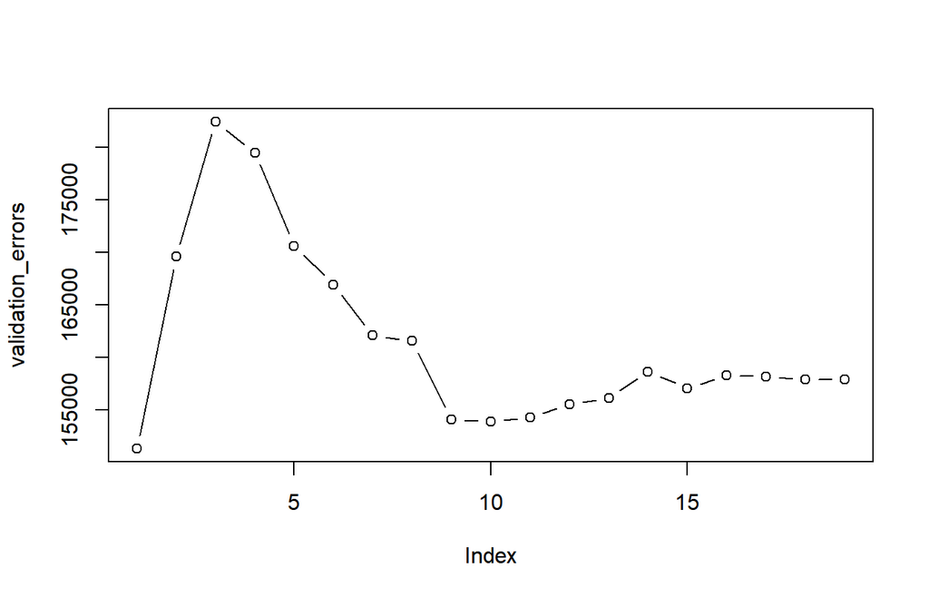

```r
# create empty vector to fill with erro values
validation_errors <- vector("double", length=19)

for(i in 1:19) {
  coef_x <- coef(best_subset, id = i)                     # extract coefficients for model size i
  pred_x <- test_m[ , names(coef_x)] %*% coef_x           # predict salary using matrix algebra
  validation_errors[i] <- mean((test$Salary - pred_x)^2)  # compute test error btwn actual & predicted salary
}

# plot validation errors
plot(validation_errors, type = "b")
```

Here, we actually see that the 1 variable model produced by the best subset approach produces the lowest test MSE! If we repeat this using a different random value seed, we will get a slightly different model that is the “best”. However, if you recall from the [Resampling Methods](http://uc-r.github.io/resampling_methods) tutorial, this is to be expected when using a training vs. testing validation approach.

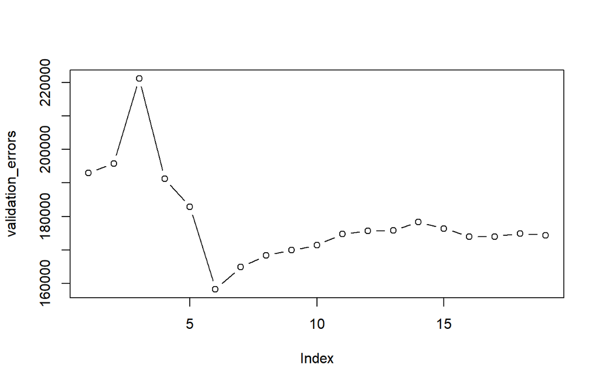

```r
# create training - testing data
set.seed(5)
sample <- sample(c(TRUE, FALSE), nrow(hitters), replace = T, prob = c(0.6,0.4))
train <- hitters[sample, ]
test <- hitters[!sample, ]

# perform best subset selection
best_subset <- regsubsets(Salary ~ ., train, nvmax = 19)

# compute test validation errors
test_m <- model.matrix(Salary ~ ., data = test)
validation_errors <- vector("double", length = 19)

for(i in 1:19) {
  coef_x <- coef(best_subset, id = i)                     # extract coefficients for model size i
  pred_x <- test_m[ , names(coef_x)] %*% coef_x           # predict salary using matrix algebra
  validation_errors[i] <- mean((test$Salary - pred_x)^2)  # compute test error btwn actual & predicted salary
}

# plot validation errors
plot(validation_errors, type = "b")
```

A more robust approach is to perform cross validation. But before we do, let’s turn our our approach above for computing test errors into a function. Our function pretty much mimics what we did above. The only complex part is how we extracted the formula used in the call to `regsubsets`. I suggest you work through this line-by-line to understand what each step is doing.

```r
predict.regsubsets <- function(object, newdata, id ,...) {
  form <- as.formula(object$call[[2]])
  mat <- model.matrix(form, newdata)
  coefi <- coef(object, id = id)
  xvars <- names(coefi)
  mat[, xvars] %*% coefi
  }
```

We now try to choose among the models of different sizes using k-fold cross-validation. This approach is somewhat involved, as we must perform best subset selection within each of the `k training sets`. First, we create a vector that allocates each observation to one of `k = 10` folds, and we create a matrix in which we will store the results.

```r
k <- 10
set.seed(1)
folds <- sample(1:k, nrow(hitters), replace = TRUE)
cv_errors <- matrix(NA, k, 19, dimnames = list(NULL, paste(1:19)))
cv_errors
```

```
##        1  2  3  4  5  6  7  8  9 10 11 12 13 14 15 16 17 18 19
##  [1,] NA NA NA NA NA NA NA NA NA NA NA NA NA NA NA NA NA NA NA
##  [2,] NA NA NA NA NA NA NA NA NA NA NA NA NA NA NA NA NA NA NA
##  [3,] NA NA NA NA NA NA NA NA NA NA NA NA NA NA NA NA NA NA NA
##  [4,] NA NA NA NA NA NA NA NA NA NA NA NA NA NA NA NA NA NA NA
##  [5,] NA NA NA NA NA NA NA NA NA NA NA NA NA NA NA NA NA NA NA
##  [6,] NA NA NA NA NA NA NA NA NA NA NA NA NA NA NA NA NA NA NA
##  [7,] NA NA NA NA NA NA NA NA NA NA NA NA NA NA NA NA NA NA NA
##  [8,] NA NA NA NA NA NA NA NA NA NA NA NA NA NA NA NA NA NA NA
##  [9,] NA NA NA NA NA NA NA NA NA NA NA NA NA NA NA NA NA NA NA
## [10,] NA NA NA NA NA NA NA NA NA NA NA NA NA NA NA NA NA NA NA
```

Now we write a for loop that performs cross-validation. In the jth fold, the elements of folds that equal j are in the test set, and the remainder are in the training set. We make our predictions for each model size, compute the test errors on the appropriate subset, and store them in the appropriate slot in the matrix `cv_errors`.

```r
for(j in 1:k) {

  # perform best subset on rows not equal to j
  best_subset <- regsubsets(Salary ~ ., hitters[folds != j, ], nvmax = 19)

  # perform cross-validation
  for( i in 1:19) {
    pred_x <- predict.regsubsets(best_subset, hitters[folds == j, ], id = i)
    cv_errors[j, i] <- mean((hitters$Salary[folds == j] - pred_x)^2)
    }
  }
```

This has given us a 10×19 matrix, of which the (i,j)th element corresponds to the test MSE for the ith cross-validation fold for the best j-variable model. We use the `colMeans` function to average over the columns of this matrix in order to obtain a vector for which the jth element is the cross-validation error for the j-variable model.

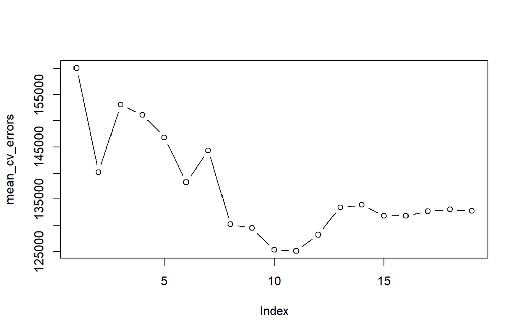

```r
mean_cv_errors <- colMeans(cv_errors)
plot(mean_cv_errors, type = "b")
```

We see that our more robust cross-validation approach selects an 11-variable model. We can now perform best subset selection on the full data set in order to obtain the 11-variable model.

```r
final_best <- regsubsets(Salary ~ ., data = hitters , nvmax = 19)
coef(final_best, 11)
```

```
##  (Intercept)        AtBat         Hits        Walks       CAtBat
##  135.7512195   -2.1277482    6.9236994    5.6202755   -0.1389914
##        CRuns         CRBI       CWalks      LeagueN    DivisionW
##    1.4553310    0.7852528   -0.8228559   43.1116152 -111.1460252
##      PutOuts      Assists
##    0.2894087    0.2688277
```

#### 2.1.3.6 Additional resources

This will get you started with approaches for performing linear model selection; however, understand that there are other approaches for more sophisticated model selection procedures. The following resources will help you learn more:

- [An Introduction to Statistical Learning](http://www-bcf.usc.edu/~gareth/ISLR/)
- [Applied Predictive Modeling](http://appliedpredictivemodeling.com/)
- [Elements of Statistical Learning](https://statweb.stanford.edu/~tibs/ElemStatLearn/)

### 2.1.4 Naive Bayes

The **Naive Bayes classifier** is a simple probabilistic classifier which is based on Bayes theorem but with strong assumptions regarding independence. Historically, this technique became popular with application in emal filtering, spam detection and document categorization.

Although it is often outperformed by other techniques, and desipite the naive design and oversimplified assumptions, this classifier can perform well in many complex real-world problems. And since it is a resource efficient algorithm that is fast and scales well, it is definitely a machine learning algorithms to have in your toolkit.

#### 2.1.4.1 tl;dr

This tutorial serves as an introduction to naive Bayes classifier and covers:

1. Replication requirment: what you will need to reproduce the analysis in this tutorial.
2. A naive overview: A closer look behind the naive Bayes classifier and its pros and cons
3. caret: Implementing with the `caret` package.
4. H2O: Implementing with the `h2o` package.
5. Learning more Where to go from here.

#### 2.1.4.2 Replication requirements

This tutorial leverages the following packages.

```r
library(rsample) # data splitting
library(dplyr)   # data transformation
library(ggplot2) # data visualization
library(caret)   # implementing with caret
library(h2o)     # implemeting with h2o
```

To illustrate the naive Bayes classifier, we will use the attrition data that has been included in the `rsample` package. The goal is to predict employee attrition.

```r
# convert some numeric variables to factors

attrition <- attrition %>%
  mutate(
    JobLevel = factor(JobLevel),
    StockOptionLevel = factor(StockOptionLevel),
    TrainingTimesLastYear = factor(TrainingTimesLastYear)
  )

# Create training (70%) and test (30%) sets for the attrition data.
# Use set.seed for reproducibility
set.seed(123)
split <- initial_split(attrition, prop = .7, strata = "Attrition")
train <- training(split)
test  <- testing(split)

# distribution of Attrition rates across train & test set
table(train$Attrition) %>% prop.table()
```

```
##
##       No      Yes
## 0.838835 0.161165
##
##       No      Yes
## 0.838835 0.161165
```

```r
table(test$Attrition) %>% prop.table()
```

```
##
##        No       Yes
## 0.8386364 0.1613636
##
##        No       Yes
## 0.8386364 0.1613636
```

#### 2.1.4.3 A Naive overview

##### 2.1.4.3.1 The idea

The naive Bayes classifier is founded on Bayesian probability, which originated from [Reverend Thomas Bayes](https://en.wikipedia.org/wiki/Thomas_Bayes). Bayesian probability incorporates the concept of conditional probability, the probabilty of event A given that event B has occurred [denoted as $P(A|B)$. In the context of our attrition data, we are seeking the probability of an employee belonging to attrition class $C_k$ (where $C_{yes} attrition$ and $C_{no}=non-attrition$) given that its predictor values are $x_1, x_2,...,x_p$. This can be written as $P(C_k|x_1, ...,x_p)$.

The Bayesian formula for claculating the probability is

$$P(C_k|X) = \frac{P(C_k) P(X|C_k)}{P(X)}$$

where:

- $P(C_k)$ is the *prior* probability of the outcome. Essentially, based on the historical data, what is the probability of an employee attriting or not. As we saw in the above section preparing our training and test sets, our prior probability of an employee attriting was about 16% and the probability of not attriting was about 84%.
- $P(X)$ is the probability of the predictor variables (same as $P(C_k|x_1,...,x_p)$.Essentially, based on the historical data, what is the probability of each observed combination of predictor variables. When new data comes in, this becomes our *evidence*.
- $P(X|C_k)$ is the *conditional probability or likelihood*. Essentially, for each class of the response variable (i.e. attrit or not attrit), what is the probability of observing the predictor values.
- $P(C_k|X)$ is called our *posterior probability*. By combining our observed information, we are updating our a priori information on probabilities to compute a posterior probability that an observation has class $C_k$.

We can re-write Eq.(1) in plaini english as:

$$posterior = \frac{prior*likelihood}{evidence}$$

Although Eq. (1) has simplistic beauty on its surface, it becomes complex and interactable as the number of predictor variables grow. In fact, to compute the posterior probability for a response variable with *m* classes and a data set with *p* predictors, Eq. (1) would require $m^p$ probabilities computed. Sor for our attrition data, we have 2 classes (attrition vs. non-attrition) and 31 variables, requiring 2,147,483,648 probabilities computed.

##### 2.1.4.3.2 The simplified classifier

Consequently, the naive Bayes classifier makes a simplifying assumption (hence the name) to allow the computation to scale. With naive Bayes, we assume that the predictor variables are *conditionally independent* of one another given the response value. This is an extremely strong assumption. We can see quickly that our attrition data violates this as we have several moderately to strongly correlated variables.

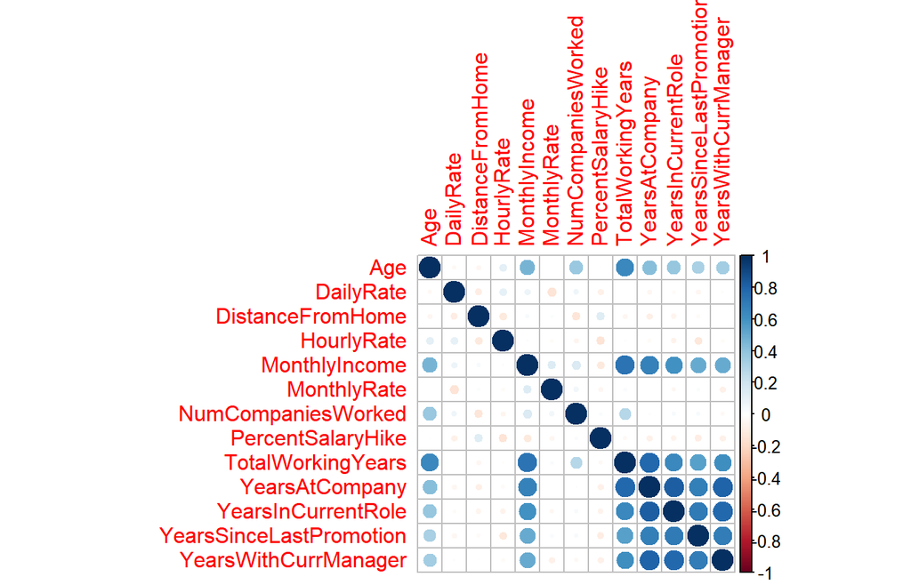

```r
train %>%
  filter(Attrition == "Yes") %>%
  select_if(is.numeric) %>%
  cor() %>%
  corrplot::corrplot()
```

However, by making this assumption, we can simplify our calculation such that the posterior probability is simply the product of the probability distribution for each individual variable conditioned on the response category (Eq. 2). Now we are only required to compute $m × p$ probabilities (this equates to 62 probabilities for our data set), a far more managable task.

$$P(C_k|X) = \prod_{i=1}^{n} P(x_i|C_k)$$

For categorical variables, this computation is quite simple as you just use the frequencies from the data. However, when including continuous predictor variables often an assumption of normality is made so that we can use the probability from the variable’s probability density function. If we pick a handful of our numeric features we quickly see assumption of normality is not always fair.

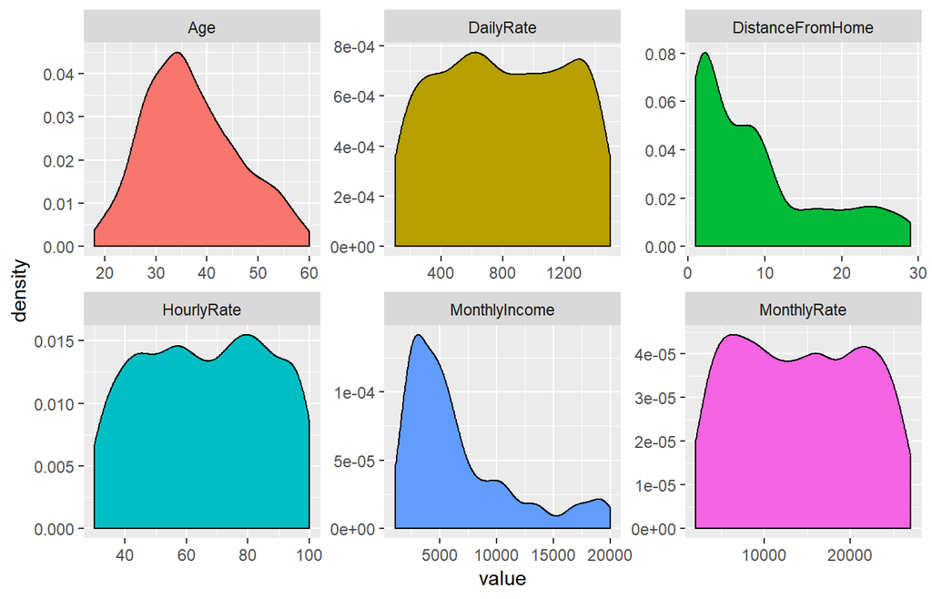

```r
train %>%
  select(Age,DailyRate,DistanceFromHome, HourlyRate, MonthlyIncome, MonthlyRate) %>%
  gather(metric, value) %>%
  ggplot(aes(value, fill=metric))+
  geom_density(show.legend = FALSE)+
  facet_wrap(~metric, scales="free")
```

Granted, some numeric features may be normalized with a Box-Cox transformation; however, as you will see in this tutorial we can also use non-parametric kernel density estimators to try get a more accurate representation of continuous variable probabilities. Ultimately, transforming the distributions and selecting an estimator is part of the modeling development and tuning process.

##### 2.1.4.3.3 Laplace Smoother

One additional issue to be aware of - since naïve Bayes uses the product of feature probabilities conditioned on each class, we run into a serious problem when new data includes a feature value that never occurs for one or more levels of a response class. What results is $P(x_i|C_k)=0$ for this individual feature adn this zero will ripple through the entire multiplication of all features and this zero will ripple through the entire multiplication of all features and will always force the posterior probability to be zero for that class.

A solution to this problem involves using the **Laplace smooother**. The Laplace smooother adds a small number to each of the counts in the frequencies for each feature, which ensures that each feature has a nonzero probability of occuring for each class. Typically, a value of one to two for the Laplace smoother is sufficient, but this is a tuning parameter to incorporate and optimize with cross validation.

##### 2.1.4.3.4 Advantage and Shortcomins

The naïve Bayes classifier is simple (both intuitively and computationally), fast, performs well with small amounts of training data, and scales well to large data sets. The greatest weakness of the naïve Bayes classifier is that it relies on an often-faulty assumption of equally important and independent features which results in biased posterior probabilities. Although this assumption is rarely met, in practice, this algorithm works surprisingly well. This is primarily because what is usually needed is not a propensity (exact posterior probability) for each record that is accurate in absolute terms but just a reasonably accurate rank ordering of propensities.

For example, we may not care about the exact posterior probability of attrition, we just want to know for a given observation, is the posterior probability of attriting larger than not attriting. Even when the assumption is violated, the rank ordering of the records’ propensities is typically preserved. Consequentely, naïve Bayes is often a surprisingly accurate algorithm; however, on average it rarely can compete with the accuracy of advanced tree-based methods (random forests & gradient boosting machines) but is definitely worth having in your toolkit.

#### 2.1.4.4 Implementation

There are several packages to apply naive Bayes (i.e., `e1071`, `klaR`, `naivebayes`, `bnclassify`). This tutorial demonstrates using the `caret` and `h2o` packages. `caret` allows us to use different naive Bayes packages above but in a common framework, and also allows for easy cross validation and tuning. `h2o` allows us to perform naive Bayes in a powerful and scalable architecture.

##### 2.1.4.4.1 `caret`

First, we apply a naive Bayes model with 10-fold cross validation, which gets 83% accuracy. Consider about 83% of our obsevations in our training set do not attrit, our overall accuracy is not better than if we just predicted “No” attrition for every observation.

```r
library(caret)

# create response and feature data
features <- setdiff(names(train), "Attrition")
x <- train[,features]
y <- train$Attrition

# set up 10-fold cross validation procedure
train_control <- trainControl(
  method = "cv",
  number = 10
)

# train model
nb.m1 <- caret::train(
  x = x,
  y = y,
  method = "nb",
  trControl = train_control
)

# results
confusionMatrix(nb.m1)
## Cross-Validated (10 fold) Confusion Matrix
##
## (entries are percentual average cell counts across resamples)
##
##           Reference
## Prediction   No  Yes
##        No  75.3  8.3
##        Yes  8.5  7.8
##
##  Accuracy (average) : 0.8311
```

We can turn the few hyperparameters that a naive Bayes model has.

- `usekernel`: parameter allows us to use a kernel density estimate for continuous variables versus a guassian density estimate,
- `adjust`: allows us to adjust the bandwidth of the kernel density (larger numbers mean more flexible density estimate),
- `fL`: allows us to incorporate the Laplace smoother.

If we just tuned our modelwith the above parameters, we are able to lift our accuracy to 85%; however, by incorporating some preprocessing of our features (normalize with Box Cox, standardize with center-scaling, and reducing with PCA), we actually get about another 2% lift in our accuracy.

```r
# set up tuning grid
search_grid <- expand.grid(
  usekernel = c(TRUE, FALSE),
  fL = 0:5,
  adjust = seq(0, 5, by = 1)
)

# train model
nb.m2 <- train(
  x = x,
  y = y,
  method = "nb",
  trControl = train_control,
  tuneGrid = search_grid,
  preProc = c("BoxCox", "center", "scale", "pca")
  )

# top 5 model
nb.m2$results %>%
  top_n(5, wt=Accuracy) %>%
  arrange(Desc(Accuracy))
```

```
##   usekernel fL adjust  Accuracy     Kappa AccuracySD   KappaSD
## 1      TRUE  1      3 0.8737864 0.4435322 0.02858175 0.1262286
## 2      TRUE  0      2 0.8689320 0.4386202 0.02903618 0.1155707
## 3      TRUE  2      3 0.8689320 0.4750282 0.02830559 0.0970368
## 4      TRUE  2      4 0.8689320 0.4008608 0.02432572 0.1234943
## 5      TRUE  4      5 0.8689320 0.4439767 0.02867321 0.1354681
```

```r
# plot search grid results
plot(nb.m2)
```

[output not shown]

```r
# results for best model
confusionMatrix(nb.m2)

## Cross-Validated (10 fold) Confusion Matrix
##
## (entries are percentual average cell counts across resamples)
##
##           Reference
## Prediction   No  Yes
##        No  80.8  9.5
##        Yes  3.1  6.6
##
##  Accuracy (average) : 0.8738
```

We can assess the accuracy on our final holdout test set. Its obvious that our model is not capturing a large percentage of our actual attritions (illustrated by our low specificity).

```r
pred <- predict(nb.m2, newdata = test)
confusionMatrix(pred, test$Attrition)
## Confusion Matrix and Statistics
##
##           Reference
## Prediction  No Yes
##        No  349  41
##        Yes  20  30
##
##                Accuracy : 0.8614
##                  95% CI : (0.8255, 0.8923)
##     No Information Rate : 0.8386
##     P-Value [Acc > NIR] : 0.10756
##
##                   Kappa : 0.4183
##  Mcnemar's Test P-Value : 0.01045
##
##             Sensitivity : 0.9458
##             Specificity : 0.4225
##          Pos Pred Value : 0.8949
##          Neg Pred Value : 0.6000
##              Prevalence : 0.8386
##          Detection Rate : 0.7932
##    Detection Prevalence : 0.8864
##       Balanced Accuracy : 0.6842
##
##        'Positive' Class : No
##
```

#### 2.1.4.5 `h2o`

Lets go ahead and start up `h2o`:

```r
# start up h2o
library(h2o)
h2o.no_progress()
h2o.init()
```

[output not shown]

We can compute a naïve Bayes model in `h2o` with `h2o.naiveBayes`. Here we use the default model with no Laplace smoother. We experience similar results on our training cross validation as we did using `caret`.

```r
# create feature names
y <- "Attrition"
x <- setdiff(names(train), y)

library(magrittr)
# h2o cannot ingest ordered factors
train.h2o <- train %>%
  mutate_if(is.factor, factor, ordered=FALSE) %>%
  as.h2o()

# train model
nb.h2o <- h2o.naiveBayes(
  x = x,
  y = y,
  training_frame = train.h2o,
  nfolds = 10,
  laplace = 0
)

# assess results
h2o.confusionMatrix(nb.h2o)
## Confusion Matrix (vertical: actual; across: predicted)  for max f1 @ threshold = 0.751627773135859:
##         No Yes    Error       Rate
## No     812  52 0.060185    =52/864
## Yes     77  89 0.463855    =77/166
## Totals 889 141 0.125243  =129/1030
## Confusion Matrix (vertical: actual; across: predicted)  for max f1 @ threshold = 0.751627773135859:
##         No Yes    Error       Rate
## No     812  52 0.060185    =52/864
## Yes     77  89 0.463855    =77/166
## Totals 889 141 0.125243  =129/1030
```

We can also do some feature preprocessing as we did with caret and tune the Laplace smoother using `h2o.grid`. We don’t see much improvement.

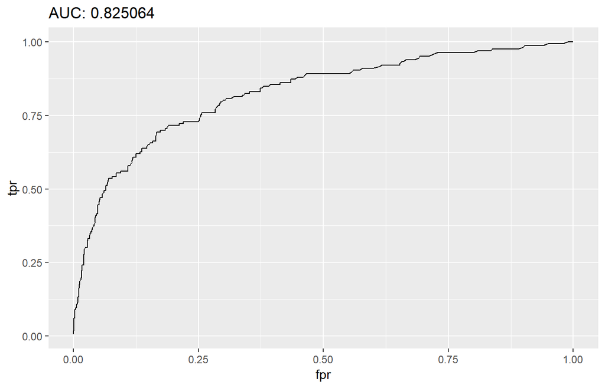

```r
# do a little preprocessing
preprocess <- preProcess(train, method = c("BoxCox", "center", "scale", "pca"))
train_pp <- predict(preprocess, train)
test_pp <- predict(preprocess, test)

# convert to h2o objects
train_pp.h2o <- train_pp %>%
  mutate_if(is.factor, factor, ordered=FALSE) %>%
  as.h2o()

test_pp.h2o <- test_pp %>%
  mutate_if(is.factor, factor, ordered=FALSE) %>%
  as.h2o()

# get new feature names -> PCA preprocessing reduced and changed some fe
x <- setdiff(names(train_pp), "Attrition")
y <- "Attrition"

# create tuning grid
hyper_params <- list(
  laplace = seq(0,5, by = 0.5)
)

# build grid search
grid <- h2o.grid(
  algorithm = "naivebayes",
  grid_id = "nb_grid",
  x = x,
  y = y,
  training_frame = train_pp.h2o,
  nfolds = 10,
  hyper_params = hyper_params
)

# sort the grid models by mse
sorted_grid <- h2o.getGrid("nb_grid", sort_by = "accuracy",
                           decreasing = TRUE)
sorted_grid
## H2O Grid Details
## ================
##
## Grid ID: nb_grid
## Used hyper parameters:
##   -  laplace
## Number of models: 11
## Number of failed models: 0
##
## Hyper-Parameter Search Summary: ordered by decreasing accuracy
##    laplace        model_ids           accuracy
## 1      3.5  nb_grid_model_8 0.8660194174757282
## 2      0.5  nb_grid_model_2 0.8621359223300971
## 3      3.0  nb_grid_model_7 0.8504854368932039
## 4      1.0  nb_grid_model_3 0.8495145631067962
## 5      1.5  nb_grid_model_4 0.8485436893203884
## 6      2.5  nb_grid_model_6 0.8466019417475728
## 7      2.0  nb_grid_model_5 0.8466019417475728
## 8      5.0 nb_grid_model_11 0.8378640776699029
## 9      0.0  nb_grid_model_1 0.8359223300970874
## 10     4.5 nb_grid_model_10 0.8194174757281554
## 11     4.0  nb_grid_model_9 0.8038834951456311
## H2O Grid Details
## ================
##
## Grid ID: nb_grid
## Used hyper parameters:
##   -  laplace
## Number of models: 11
## Number of failed models: 0
##
## Hyper-Parameter Search Summary: ordered by decreasing accuracy
##    laplace        model_ids           accuracy
## 1      2.5  nb_grid_model_5 0.8572815533980582
## 2      5.0 nb_grid_model_10 0.8572815533980582
## 3      3.0  nb_grid_model_6 0.8533980582524272
## 4      2.0  nb_grid_model_4 0.8504854368932039
## 5      1.5  nb_grid_model_3 0.8466019417475728
## 6      4.5  nb_grid_model_9 0.8407766990291262
## 7      0.5  nb_grid_model_1 0.8398058252427184
## 8      4.0  nb_grid_model_8 0.8339805825242719
## 9      3.5  nb_grid_model_7 0.8281553398058252
## 10     1.0  nb_grid_model_2 0.8194174757281554
## 11     0.0  nb_grid_model_0 0.8009708737864077

# grab top model id
best_h2o_model <- sorted_grid@model_ids[[1]]
best_model <- h2o.getModel(best_h2o_model)

# confusion matrix of best model
h2o.confusionMatrix(best_model)
## Confusion Matrix (vertical: actual; across: predicted)  for max f1 @ threshold = 0.391017417416149:
##         No Yes    Error       Rate
## No     795  69 0.079861    =69/864
## Yes     59 107 0.355422    =59/166
## Totals 854 176 0.124272  =128/1030

# ROC curve
auc <- h2o.auc(best_model, xval = TRUE)
fpr <- h2o.performance(best_model, xval = TRUE) %>% h2o.fpr() %>% .[['fpr']]
tpr <- h2o.performance(best_model, xval = TRUE) %>% h2o.tpr() %>% .[['tpr']]

data.frame(fpr = fpr,
           tpr = tpr) %>%
  ggplot(aes(fpr, tpr))+
  geom_line()+
  ggtitle(sprintf('AUC: %f', auc))
```

Once we’ve identified the optimal model we can assess on our test set.

```r
# evaluate on test set
h2o.performance(best_model, newdata = test_pp.h2o)
## H2OBinomialMetrics: naivebayes
##
## MSE:  0.09943567
## RMSE:  0.3153342
## LogLoss:  0.3329187
## Mean Per-Class Error:  0.2665369
## AUC:  0.8476469
## pr_auc:  0.5998538
## Gini:  0.6952937
##
## Confusion Matrix (vertical: actual; across: predicted) for F1-optimal threshold:
##         No Yes    Error     Rate
## No     349  20 0.054201  =20/369
## Yes     34  37 0.478873   =34/71
## Totals 383  57 0.122727  =54/440
##
## Maximum Metrics: Maximum metrics at their respective thresholds
##                         metric threshold    value idx
## 1                       max f1  0.538305 0.578125  56
## 2                       max f2  0.207728 0.678571 134
## 3                 max f0point5  0.538305 0.618729  56
## 4                 max accuracy  0.538305 0.877273  56
## 5                max precision  0.978089 1.000000   0
## 6                   max recall  0.000399 1.000000 399
## 7              max specificity  0.978089 1.000000   0
## 8             max absolute_mcc  0.538305 0.511510  56
## 9   max min_per_class_accuracy  0.216581 0.785908 133
## 10 max mean_per_class_accuracy  0.207728 0.794362 134
##
## Gains/Lift Table: Extract with `h2o.gainsLift(<model>, <data>)` or `h2o.gainsLift(<model>, valid=<T/F>, xval=<T/F>)`
## H2OBinomialMetrics: naivebayes
```

```r
# predict new data
h2o.predict(nb.h2o, newdata = test_pp.h2o)
```

```
##   predict        No         Yes
## 1      No 0.9851309 0.014869060
## 2      No 0.9109746 0.089025413
## 3      No 0.9947524 0.005247592
## 4      No 0.9694504 0.030549563
## 5      No 0.9683716 0.031628419
## 6      No 0.9836910 0.016308996
##
## [440 rows x 3 columns]
##   predict        No         Yes
## 1      No 0.9851309 0.014869060
## 2      No 0.9109746 0.089025413
## 3      No 0.9947524 0.005247592
## 4      No 0.9694504 0.030549563
## 5      No 0.9683716 0.031628419
## 6      No 0.9836910 0.016308996
##
## [440 rows x 3 columns]
```

```r
# shut down h2o
h2o.shutdown(prompt = FALSE)
```

```
## [1] TRUE
## [1] TRUE
```

#### 2.1.4.6 Learning more

Although we did not see much improvement over the baseline response class proportions in this example, the naïve Bayes classifier is often hard to beat in terms of CPU and memory consumption as shown by Huang, J. (2003), and in certain cases its performance can be very close to more complicated and slower techniques. Consquently, its a solid technique to have in your toolkit. If you want to dig deeper into this classifier, I would start with:

- [Andrew Moore’s tutorials](http://www.cs.cmu.edu/~./awm/tutorials/naive.html)
- [Naive Bayes classifiers by Kevin Murphy](https://datajobsboard.com/wp-content/uploads/2017/01/Naive-Bayes-Kevin-Murphy.pdf)
- [Data Mining and Predictive Analytics, Ch. 14](https://www.amazon.com/Mining-Predictive-Analytics-Daniel-Chantal/dp/8126559136/ref=sr_1_1?ie=UTF8&qid=1524231609&sr=8-1&keywords=data+mining+and+predictive+analytics+2nd+edition+%2C+by+larose)

### 2.1.5 Logistic regression

Logistic regression (aka logit regressionor logit model) was developed by statistician David Cox in 1958 and is a regression model where the response variable Y is categorical. Logistic regression allows us to estimate the probability of a categorical response based on one or more predictor variables ($X$). It allows one to say that the presence of a predictor increases (or decreases) the probability of a given outcome by a specific percentage. This tutorial covers the case when Y is binary — that is, where it can take only two values, “0” and “1”, which represent outcomes such as pass/fail, win/lose, alive/dead or healthy/sick. Cases where the dependent variable has more than two outcome categories may be analysed with multinomial logistic regression, or, if the multiple categories are ordered, in ordinal logistic regression. However, *discriminant analysis* has become a popular method for multi-class classification so our next tutorial will focus on that technique for those instances.

#### 2.1.5.1 tl;dr

This turorial serves as an introudction to logistic regression and covers:

1. Replication requirements: What you’ll need to reproduce the analysis in this tutorial
2. Why logistic regression: Why use logistic regression?
3. Preparing our data: Prepare our data for modeling
4. Simple Logistic regression: Predicting the probability of response Y with a single predictor variable X
5. Multiple Logistic regression: Predicting the probability of response Y with multiple predictor variables $X_1, X_2,...X_p$
6. Model evaluation & diagnostics: How well does the model fit the data? Which predictors are most important? Are the predictions accurate?

#### 2.1.5.2 Replication requirements

This tutorial primarily leverages the `Default` data provided by the `ISLR` package. This is simulated data set containing information on ten thousand customers such as whether the customer defaulted, is a student, the average balance carried by the customer and the income of the customer. We’ll also use a few packages that provide data manipulation, visualization, pipeline modeling functions, and model output tidying functions.

```r
library(tidyverse)
library(modelr)
library(broom)

# load data
(default <- as_tibble(ISLR::Default))
```

```
## # A tibble: 10,000 x 4
##    default student balance income
##    <fct>   <fct>     <dbl>  <dbl>
##  1 No      No         730. 44362.
##  2 No      Yes        817. 12106.
##  3 No      No        1074. 31767.
##  4 No      No         529. 35704.
##  5 No      No         786. 38463.
##  6 No      Yes        920.  7492.
##  7 No      No         826. 24905.
##  8 No      Yes        809. 17600.
##  9 No      No        1161. 37469.
## 10 No      No           0  29275.
## # ... with 9,990 more rows
```

#### 2.1.5.3 Why Logistic regression

Linear regression is not approproate in the case of qualitative response. Why not? Suppose that we are trying to predict the medical condition of a patient in the emergency room on the basis of her symptoms. In this simplified example, there are three possible diagnoses: *stroke*, *drug overdose*, and *epileptic seizure*. We could consider encoding these values as a quantitative response variable, `Y` , as follows:

$$Y = 1, if stroke; //
2, if drug overdose;
3, if epileptic seizure$$

Using this coding, least squares could be used to fit a linear regression model to predict Y on the basis of a set of predictors $X_1,..., X_p$. . Unfortunately, this coding implies an ordering on the outcomes, putting drug overdose in between stroke and epileptic seizure, and insisting that the difference between stroke and drug overdose is the same as the difference between drug overdose and epileptic seizure. In practice there is no particular reason that this needs to be the case. For instance, one could choose an equally reasonable coding,

$$Y = 1, if epileptic seizure;
2, if stroke;
3 if drug overdose$$

which would imply a totally different relationship among the three conditions. Each of these codings would produce fundamentally different linear models that would ultimately lead to different sets of predictions on test observations.

```r
default %>% colnames()
```

```
## [1] "default" "student" "balance" "income"
```

```r
lm <- lm(default ~ balance, data=default)
glm <- glm(default ~ balance, data=default, family = "binomial")
```

$$p(x) = \frac{e^{\beta_o + \beta_1X}}{1+e^{\beta_o + \beta_1X}$$

#### 2.1.5.4 Preparing our data

As in the regression tutorial, we will split our data into a training (60%) and testing (40%) data sets so we can assess how well our model performs on an out-of-sample data set.

```r
set.seed(123)
sample <- sample(c(TRUE, FALSE), nrow(default), replace = T, prob = c(0.6,0.4))
train <- default[sample, ]
test <- default[!sample, ]
```

#### 2.1.5.5 Simple logistic regression

We will fit a logistic regression model in order to predict the probability of a customer defaulting based on the average balance carried by the customer. The `glm` function fits generalized linear models, a class of models that includes logistic regression. The syntax of the `glm` function is similar to that of `lm`, except that we must pass the argument `family = binomial` in order to tell R to run a logistic regression rather than some other type of generalized linear model.

```r
model1 <- glm(default ~ balance, family = "binomial",
             data = train)
```

In the background the `glm`, uses *maximum likelihood* to fit the model. The basic intuition behind using maximum likelihood to fit a logistic regression model is as follows: we seek estimates for $\beta_0$ and $\beta_1$ such that the predicted probability $p(x_i)$ of default for each individual, using Eq.1, corresponds as closely as possible to the individual’s observed default status. In other words, we try to find $\beta_0$ and $\beta_1$ 1 such that plugging these estimates into the model for $p(X)$, given in Eq. 1, yields a number close to one for all individuals who defaulted, and a number close to zero for all individuals who did not. This intuition can be formalized using a mathematical equation called a likelihood function:

$$l(\beta_0, \beta_1) = \Pi_{i:y_i-1} p(x_i) \Pi_{i':y_i'=0}(1-p(x_i'))$$

The estimates $\beta_0 and \beta_1$ are chosen to *maximize* this likelihood function. Maximum likelihood is very general approach that is used to fit many of the non-linear models that we will examine in future totorial. What resuls is an S-shaped probability curve illustrated below (note that to plot the logistic regression fit line, we need to convert our response variable to a $[0,1]$ binary coded variable)

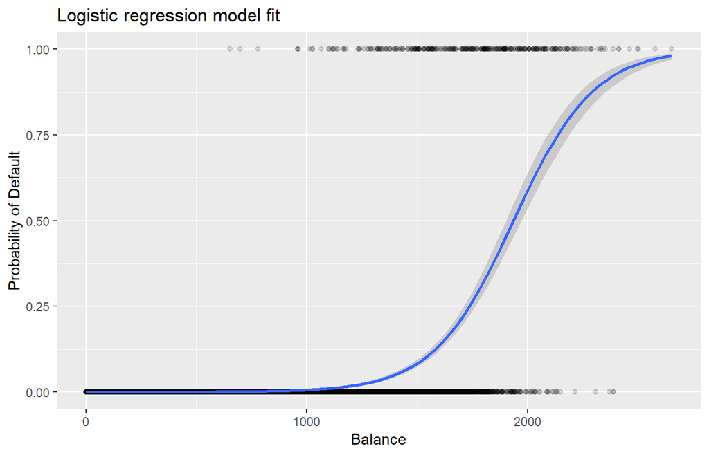

```r
default %>%
  mutate(prob = ifelse(default == "Yes", 1, 0)) %>%
  ggplot(aes(balance, prob)) +
  geom_point(alpha = .15) +
  geom_smooth(method = "glm", method.args = list(family = "binomial")) +
  ggtitle("Logistic regression model fit") +
  xlab("Balance") +
  ylab("Probability of Default")
```

Similar to linear regression we can assess the model using `summary` or `glance`. Note that the coefficient output format is similar to what we saw in linear regression; however, the goodness-of-fit details at the bottom of `summary` differ. We’ll get into this more later but just note that you see the word deviance. Deviance is analogous to the sum of squares calculations in linear regression and is a measure of the lack of fit to the data in a logistic regression model. The null deviance represents the difference between a model with only the intercept (which means “no predictors”) and a saturated model (a model with a theoretically perfect fit). The goal is for the model deviance (noted as *Residual deviance*) to be lower; smaller values indicate better fit. In this respect, the null model provides a baseline upon which to compare predictor models.

```r
summary(model1)
```

```
##
## Call:
## glm(formula = default ~ balance, family = "binomial", data = train)
##
## Deviance Residuals:
##     Min       1Q   Median       3Q      Max
## -2.2905  -0.1395  -0.0528  -0.0189   3.3346
##
## Coefficients:
##               Estimate Std. Error z value Pr(>|z|)
## (Intercept) -1.101e+01  4.887e-01  -22.52   <2e-16 ***
## balance      5.669e-03  2.949e-04   19.22   <2e-16 ***
## ---
## Signif. codes:  0 '***' 0.001 '**' 0.01 '*' 0.05 '.' 0.1 ' ' 1
##
## (Dispersion parameter for binomial family taken to be 1)
##
##     Null deviance: 1723.03  on 6046  degrees of freedom
## Residual deviance:  908.69  on 6045  degrees of freedom
## AIC: 912.69
##
## Number of Fisher Scoring iterations: 8
##
## Call:
## glm(formula = default ~ balance, family = "binomial", data = train)
##
## Deviance Residuals:
##     Min       1Q   Median       3Q      Max
## -2.2905  -0.1395  -0.0528  -0.0189   3.3346
##
## Coefficients:
##               Estimate Std. Error z value Pr(>|z|)
## (Intercept) -1.101e+01  4.887e-01  -22.52   <2e-16 ***
## balance      5.669e-03  2.949e-04   19.22   <2e-16 ***
## ---
## Signif. codes:  0 '***' 0.001 '**' 0.01 '*' 0.05 '.' 0.1 ' ' 1
##
## (Dispersion parameter for binomial family taken to be 1)
##
##     Null deviance: 1723.03  on 6046  degrees of freedom
## Residual deviance:  908.69  on 6045  degrees of freedom
## AIC: 912.69
##
## Number of Fisher Scoring iterations: 8
```

##### 2.1.5.5.1 Asessing coefficients

The below table shows the coefficient estimates and related information that result from fitting a logistic regression model in order to predict the probability of default = Yes using balance. Bear in mind that the coefficient estimates from logistic regression characterize the relationship between the predictor and response variable on a *log-odds* scale (see Ch. 3 of ISLR1 for more details). Thus, we see that $\hatβ_1=0.0057$ ; this indicates that an increase in balance is associated with an increase in the probability of default. To be precise, a one-unit increase in balance is associated with an increase in the log odds of default by 0.0057 units.

```r
broom::tidy(model1)
```

```
## # A tibble: 2 x 5
##   term         estimate std.error statistic   p.value
##   <chr>           <dbl>     <dbl>     <dbl>     <dbl>
## 1 (Intercept) -11.0      0.489        -22.5 2.66e-112
## 2 balance       0.00567  0.000295      19.2 2.53e- 82
##          term      estimate   std.error statistic       p.value
## 1 (Intercept) -11.006277528 0.488739437 -22.51972 2.660162e-112
## 2     balance   0.005668817 0.000294946  19.21985  2.525157e-82
```

We can further interpret the *balance* coefficient as - for every one dollar increase in monthly balance carried, the odds of the customer defaulting increases by a factor of 1.0057.

```r
exp(coef(model1))
```

```
##  (Intercept)      balance
## 1.659718e-05 1.005685e+00
```

Many aspects of the coefficient output are similar to those discussed in the linear regression output. For example, we measure the confidence intervals and accuracy of the coefficient estimates by computing their standard errors. For instance, $\hatβ_1$ has a p-value < $2e-16$ and the probability of defaulting. We can also use the standard errors to get confidence intervals as we did in the linear regression tutorial:

```r
confint(model1)
```

```
##                     2.5 %        97.5 %
## (Intercept) -12.007610373 -10.089360652
## balance       0.005111835   0.006269411
```

##### 2.1.5.5.2 Making predictions

Once the coefficients have benn estimated, it is a simple matter to comupte the probability of default for any given credit card balance. Mathematically, using the coefficient estimates from our model we predict that the default probability for an individual with a balance of $1,000 is less than 0.5%

We can predict the probability of defaulting in R using the `predict` function (be sure to include `type = "response"`). Here we compare the probability of defaulting based on balances of `$1000 and $2000`. As you can see as the balance moves from `$1000 to $2000` the probability of defaulting increases signficantly, from 0.5% to 58%!

```r
predict(model1,
        data.frame(balance = c(1000, 2000)),
        type = "response")
```

```
##           1           2
## 0.004785057 0.582089269
##           1           2
## 0.004785057 0.582089269
```

One can also use qualitative predictors with the logistic regression model. As an example, we can fit a model that uses the `student` variable.

```r
model2 <- glm(default ~ student, family = "binomial", data = train)

tidy(model2)
```

```
## # A tibble: 2 x 5
##   term        estimate std.error statistic p.value
##   <chr>          <dbl>     <dbl>     <dbl>   <dbl>
## 1 (Intercept)   -3.55     0.0934    -38.1  0
## 2 studentYes     0.441    0.149       2.96 0.00311
##          term   estimate  std.error statistic     p.value
## 1 (Intercept) -3.5534091 0.09336545 -38.05914 0.000000000
## 2  studentYes  0.4413379 0.14927208   2.95660 0.003110511
```

```r
predict(model2, data.frame(student = factor(c("Yes", "No"))), type = "response")
```

```
##          1          2
## 0.04261206 0.02783019
##          1          2
## 0.04261206 0.02783019
```

#### 2.1.5.6 Multiple logistic regression

We can also extend our model as seen in Eq. 1 so that we can predict a binary response using multiple predictors where $X = (X_1,..., X_p$) are p predictors:

$$p(X) = \frac{e^{\beta_0+\beta_1X_1+...+\beta_pX_p}}{1+e^{\beta_0+\beta_1X_1+...+\beta_pX_p}}$$

Let’s go ahead and fit a model that predicts the probability of *default* based on the balance, income (in thousands of dollars), and student status variables. There is a surprising result here. The p-values associated with `balance` and `student=Yes` status are very small, indicating that each of these variables is associated with the probability of defaulting. However, the coefficient for the student variable is negative, indicating that students are less likely to default than non-students. In contrast, the coefficient for the student variable in model 2, where we predicted the probability of default based only on student status, indicated that students have a greater probability of defaulting. What gives?

```r
model3 <- glm(default ~ balance + income + student, family = "binomial", data = train)
tidy(model3)
```

```
## # A tibble: 4 x 5
##   term            estimate std.error statistic  p.value
##   <chr>              <dbl>     <dbl>     <dbl>    <dbl>
## 1 (Intercept) -10.9        0.648       -16.8   1.47e-63
## 2 balance       0.00591    0.000310     19.0   7.90e-81
## 3 income       -0.00000501 0.0000108    -0.465 6.42e- 1
## 4 studentYes   -0.809      0.313        -2.58  9.78e- 3
```

This simple example illustrates the dangers and subtleties associated with performing regressions involving only a single predictor when other predictors may also be relevant. The results obtained using one predictor may be quite different from those obtained using multiple predictors, especially when there is correlation among the predictors. This phenomenon is known as *confounding*.

In the case of multiple predictor variables sometimes we want to understand which variable is the most influential in predicting the response (`Y`) variable. We can do this with `varImp` from the `caret` package. Here, we see that *balance* is the most important by a large margin whereas student status is less important followed by income (which was found to be insignificanbt anyways (p = .64)).

```r
caret::varImp(model3)
```

```
##               Overall
## balance    19.0403764
## income      0.4647343
## studentYes  2.5835947
```

As before, we can easily make predictions with this model. For example, a student with a credit card balance of $1,500$ and an income of $40,000$ has an estimated probability of default of

A non-student with the same balance and income has an estimated probability of default of

```r
new.df <- tibble(balance = 1500, income = 40, student = c("Yes", "No"))
predict(model3, new.df, type = "response")
```

```
##          1          2
## 0.05437124 0.11440288
##          1          2
## 0.05437124 0.11440288
```

Thus, we see that for the given balance and income (although income is insignificant) a student has about half the probability of defaulting than a non-student.

#### 2.1.5.7 Mode evaluation & diagnostics

So far three logistic regression models have been built and the coefficients have been examined. However, some critical questions remain. Are the models any good? How well does the model fit the data? And how accurate are the predictions on an out-of-sample data set?

##### 2.1.5.7.1 Goodness of fit

In the linear regression tutorial we saw how the F-statistic, $R^2$ and adjusted $R^2$ and residual diagnostics inform us of how good the model fits the data. Here, we will look at a few ways to assess the goodness of fit ofr our logit models.

##### 2.1.5.7.2 Likelihood ratio test

First, we can use a *Likelihood Ratio Test* to assess if our models are improving the fit. Adding predictor variables to a model will almost always improve the model fit (i.e. increase the log likelihood and reduce the model deviance compared to the null deviance), but it is necessary to test whether the observed difference in model fit is statistically significant. We can use *anova* to perform this test. The results indicate that, compared to `model1`, `model3` reduces the residual deviance by over 13 (remember, a goal of logistic regression is to find a model that minimizes deviance residuals). More imporantly, this improvement is statisticallly significant at p = 0.001. This suggests that `model3` does provide an improved model fit.

```r
anova(model1, model3, test="Chisq")
## Analysis of Deviance Table
##
## Model 1: default ~ balance
## Model 2: default ~ balance + income + student
##   Resid. Df Resid. Dev Df Deviance Pr(>Chi)
## 1      6045     908.69
## 2      6043     895.02  2   13.668 0.001076 **
## ---
## Signif. codes:  0 '***' 0.001 '**' 0.01 '*' 0.05 '.' 0.1 ' ' 1
```

##### 2.1.5.7.3 pseudo $R^2$

Unlike linear regression with ordinary least squares estimation, there is no $R^2$ statistic which explains the proportion of variance in the dependent variable that is explained by the predictors. However, there are a number of pseudo $R^2$ metrics that could be of value. Most notable is [McFadden’s $R^2$](http://stats.stackexchange.com/questions/82105/mcfaddens-pseudo-r2-interpretation), which is defined as

$$1 - \frac{ln(LM_1)}{ln(LM_0)}$$

where $ln(LM_1)$ is the log likelihood value for the fitted model and ln(LM_0) is the log likelohood for the null model with only an intercept as a predictor. The measure ranges from 0 to just under 1, with values closer to zero indicating that the model has no predictive power. However, unlike $R^2$ in linear regression, models rarely achieve a high McFadden $R^2$. In fact, in McFadden’s own words models with a McFadden pseudo $R^2 ~ 0.40$ represents a very good fit. We can assess McFadden’s pseudo $R^2$ values for our models with:

```r
list(
  model1 = pscl::pR2(model1)["McFadden"],
  model2 = pscl::pR2(model2)["McFadden"],
  model3 = pscl::pR2(model3)["McFadden"])
```

```
## $model1
##  McFadden
## 0.4726215
##
## $model2
##    McFadden
## 0.004898314
##
## $model3
##  McFadden
## 0.4805543
```